# Create/enhance data visualisations with scRUtils

I-Hsuan Lin

07/29/2026

#### Package

scRUtils 0.4.2

# 1 Overview

`scRUtils` provides various utilities for visualising and functional analysis of RNA-seq data, particularly single-cell dataset. It evolved from a collection of helper functions that were used in our in-house scRNA-seq processing workflow.

The documentation of this package is divided into 5 sections:

1. [Introduction to scRUtils](https://ycl6.github.io/scRUtils/scRUtils-intro.html)
2. [General data visualisations](https://ycl6.github.io/scRUtils/basics.html)
3. [Single-cell visualisations](https://ycl6.github.io/scRUtils/singleCell.html)
4. [Markers and DEGs](https://ycl6.github.io/scRUtils/markers.html)
5. [Demo datasets](https://ycl6.github.io/scRUtils/demoData.html)

This vignette (#2) will demonstrate functions for general visualisation purposes.

# 2 Load packages

To use `scRUtils` and relevant packages in a R session, we load them using the `library()` command.

```r
library(scRUtils)

library(ggforce)
library(ggplot2)
library(scater)
```

# 3 Usage

## 3.1 Jupyter Notebook-specific

### 3.1.1 Change `repr.plot.*` behaviour

The `fig()`, function uses `options()` to change the behaviour of `repr.plot.*`. It provides a quick and easy way to change plot size and other `repr.plot.*` behaviours when running R in a **Jupyter Notebook**. If use without indicating any argument, the plot behaviour will be reset to default. The `reset.fig()` is an alias of `fig()`.

The example below is not evaluated as the function has no effect in R Markdown.

```r
library(ggplot2)

# Change plot area width to 8 inches and height to 5 inches
fig(width = 8, height = 5)
ggplot(mpg, aes(class)) + geom_bar()

# Reset to default settings
fig()

# Change plot wider and taller
fig(width = 14, height = 10)
ggplot(mpg, aes(class)) + geom_bar()

# Alias of fig()
reset.fig()
```

## 3.2 Discrete palette

### 3.2.1 The `c30()` and `c40()` palettes

The `c30()` palette has 30 unique colours and `c40()` palette has 40 unique colours. The `c40()` colour palette is taken from `plotScoreHeatmap()` of the *SingleR* package (which itself is based on and Okabe-Ito colors).

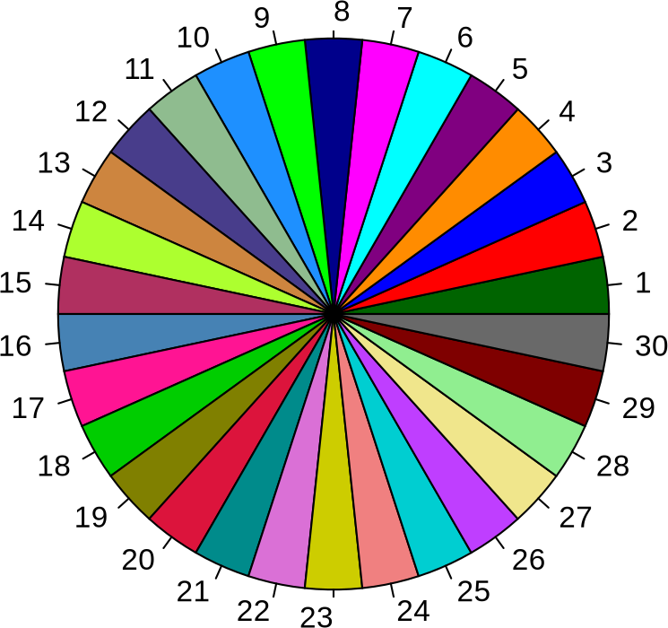

```r
# Show colours as pie charts
pie(rep(1,30), col = c30(), radius = 1.05)
```

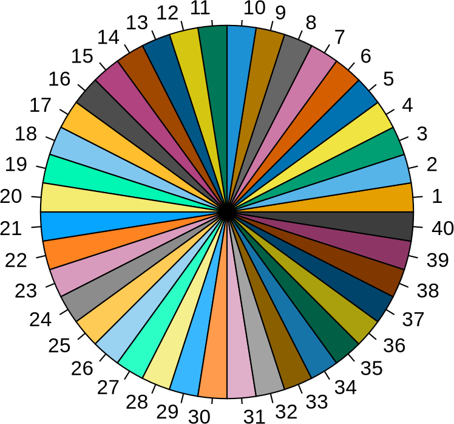

```r
pie(rep(1,40), col = c40(), radius = 1.05)
```

### 3.2.2 Choose discrete colours

The `choosePalette()` function takes a character vector of features and optionally a vector of color codes to evaluate if the supplied color codes has sufficient number of colours. It returns a named vector of color codes based on the input features, with the same length as the unique features.

By default, it uses the `c30()` palette when no more than 30 colours are required, then the `c40()` palette, and lastly the `rainbow()` colour palette when requiring more than 40 colours.

The example below shows using a character vector of 10 letters as input and `choosePalette()` returns 5 colours.

```r
feat <- rep(LETTERS[1:5], 2)
feat
```

```
##  [1] "A" "B" "C" "D" "E" "A" "B" "C" "D" "E"
```

```r
choosePalette(feat) # use c30()
```

```
##         A         B         C         D         E
## "#006400" "#ff0000" "#0000ff" "#ff8c00" "#800080"
```

Next example shows using a factor of 15 letters and 3 levels as input and `choosePalette()` returns 3 of the 10 colours from the `rainbow(10)` colour palette.

```r
feat <- factor(rep(LETTERS[1:3], 5))
feat
```

```
##  [1] A B C A B C A B C A B C A B C
## Levels: A B C
```

```r
choosePalette(feat, rainbow(10))
```

```
##         A         B         C
## "#FF0000" "#FF9900" "#CCFF00"
```

## 3.3 Parallel sets diagram

### 3.3.1 Add nudged labels in a parallel sets diagram

The `geom_parallel_sets_labs()` function in this package is the same function as `geom_parallel_sets_labels()` from the *ggforce* package but with the ability to nudge labels at a fixed distance. It is especially useful when the labels are too long to fit inside the bars depicting the discrete categories. A pull request of the nudge enhancement has been submitted to its GitHub repository, *ggforce*, awaiting approval.

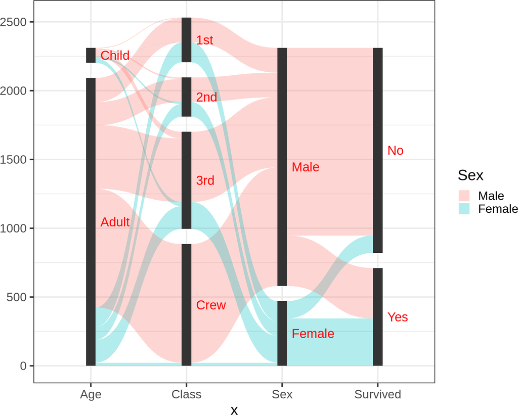

```r
library(ggforce)
data <- as.data.frame(Titanic)
data <- gather_set_data(data, 1:4)

# Use nudge_x to offset and hjust = 0 to left-justify label
ggplot(data, aes(x, id = id, split = y, value = Freq)) +
  geom_parallel_sets(aes(fill = Sex), alpha = 0.3, axis.width = 0.1) +
  geom_parallel_sets_axes(axis.width = 0.1) +
  geom_parallel_sets_labs(colour = "red", size = 6, angle = 0,
                          nudge_x = 0.1, hjust = 0) +
  theme_bw(20)
```

## 3.4 Create a 2-variable parallel sets diagram

The `plotParallel()` function uses the *ggforce* package to produce a parallel sets diagram for visualising interaction between 2 variables. The inputs are two character vectors containing membership information.

The example below uses the `Titanic` dataset to show the class and age of the passengers.

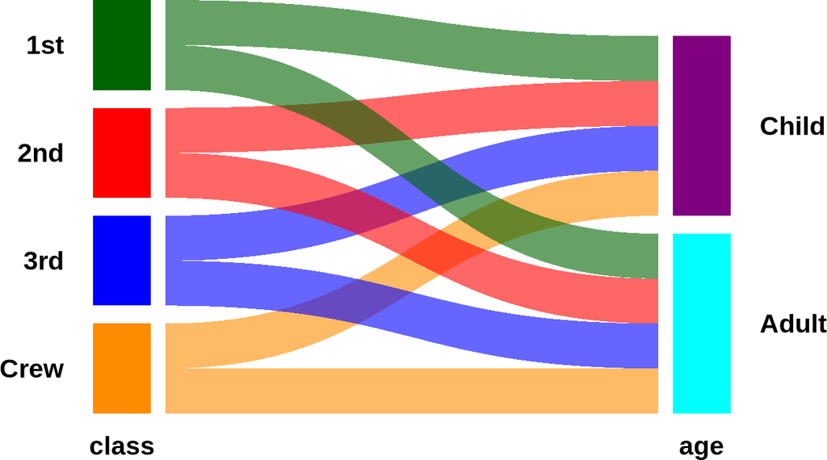

```r
data <- as.data.frame(Titanic)
plotParallel(data$Class, data$Age, labels = c("class", "age"))
```

We can also use `plotParallel()` to show cell-specific features of a single-cell dataset, such as clustering and cell type assignment.

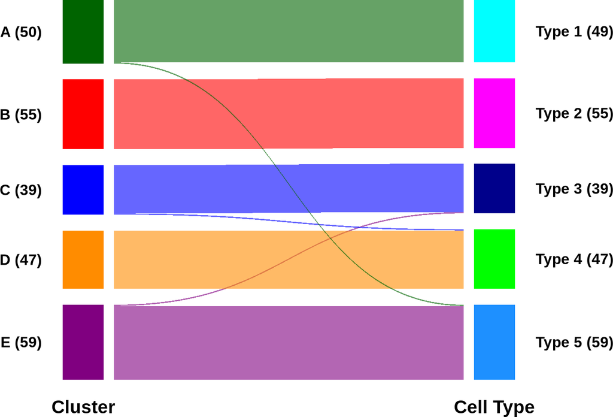

```r
data(sce)

plotParallel(sce$label, sce$CellType, labels = c("Cluster", "Cell Type"),
             add_counts = TRUE, text_size = 4)
```